# Analyzing the Spotify Daily Song Charts

#### By Timothy Wong, Fall 2019

[figure not shown]

Photo courtesy of [Pinterest](https://www.pinterest.com/pin/226235581266794575/?lp=true)

## Introduction

Music has always played a major role in shaping humanity. For over 40,000 years, humans have written and played music. It has brought communities together, forged friendships, and even introduced love into people's lives. Music has helped influence and shape generations of societies. It can take many forms and holds many purposes. Music is a part of religion, government, tradition, entertainment, and more.

Now more than ever, we are able to keep track of data points in relation to music. As the world grows more technologically advanced, so does the realm of music. Analyzing datasets from applications such as Apple Music, Soundcloud, and Spotify can reveal certain music trends that aren't immediately apparent. This tutorial will explore [Spotify's daily rankings](https://www.kaggle.com/edumucelli/spotifys-worldwide-daily-song-ranking/data) in the US for the year 2017. This dataset was originally put together by Eduardo on Kaggle. The data used in this dataset was collected from Spotify's regional chart [data](https://spotifycharts.com/regional). The dataset is not perfect as there are a few missing data points, but overall the datset serves its purpose. Throughout this tutorial, I will be conducting exploratory analysis into the songs, artists, and trends of the most streamed songs of 2017!

## Getting Started: Data Curration, Parsing, and Management

### Required Libraries

For this tutorial, I will be using [Python 3](https://www.python.org/downloads/), as well as some very popular and easily accessible Python libraries. These libraries and tools will allow us to perform more analysis on our dataset! These libraries include: [Pandas](https://pandas.pydata.org/pandas-docs/stable/), [numpy](https://docs.scipy.org/doc/numpy/user/), [seaborn](https://seaborn.pydata.org/), [matplotlib](https://matplotlib.org/contents.html), and more.

```python
import matplotlib.pyplot as plt
import numpy as np
import pandas as pd
import seaborn as sns

import warnings

warnings.filterwarnings('ignore')
```

### Reading the Data

The first step of this project is to find and collect the dataset. [Kaggle](https://www.kaggle.com/) provides many dataset repositories in a large range of subjects. The dataset I will be using for this tutorial can be found [here](https://www.kaggle.com/edumucelli/spotifys-worldwide-daily-song-ranking/data). Just by initially looking at the description of the dataset, we can see that there is going to be way too much information, but we will deal with that later.

To follow along with this tutorial, navigate to the [Kaggle](https://www.kaggle.com/edumucelli/spotifys-worldwide-daily-song-ranking/data) webpage for this dataset and click on the Download button. You should now be able to see the file spotifys-worldwide-daily-song-ranking.zip. Opening the zip file should reveal data.csv. This is the csv file that we will be using to collect our data. We will read the data.csv file into a pandas dataframe in order to better analyze the data.

```python
data = pd.read_csv('data.csv')
data.head()
```

|  | Position | Track Name | Artist | Streams | URL | Date | Region |
| --- | --- | --- | --- | --- | --- | --- | --- |
| 0 | 1 | Reggaetón Lento (Bailemos) | CNCO | 19272 | https://open.spotify.com/track/3AEZUABDXNtecAO... | 2017-01-01 | ec |
| 1 | 2 | Chantaje | Shakira | 19270 | https://open.spotify.com/track/6mICuAdrwEjh6Y6... | 2017-01-01 | ec |
| 2 | 3 | Otra Vez (feat. J Balvin) | Zion & Lennox | 15761 | https://open.spotify.com/track/3QwBODjSEzelZyV... | 2017-01-01 | ec |
| 3 | 4 | Vente Pa' Ca | Ricky Martin | 14954 | https://open.spotify.com/track/7DM4BPaS7uofFul... | 2017-01-01 | ec |
| 4 | 5 | Safari | J Balvin | 14269 | https://open.spotify.com/track/6rQSrBHf7HlZjtc... | 2017-01-01 | ec |

Let's take a look at the dataframe we have created. There are currently 7 columns in the dataframe:

```
Position: The ranking of the song on that day
Track Name: The name of the song
Artist: The singer(s) of the song
Streams: Total number of streams for that song on that day
URL: Where to find the song online
Date: The day of that ranking
Region: 2 letter region code to represent different countries
```

### Data Processing

Since the raw data from the Spotify charts has already been processed into the dataset that we downloaded from Kaggle, there isn't as much tidying or modifying of the data required as if we had read in the raw data itself. However, that doesn't mean that our dataframe is exactly how we want it. Right now, the dataframe contains the daily rankings for 52 different countries. We are only interested in the US for this tutorial, so we will go ahead and remove all of the other countries

```python
data = data[data['Region'] == 'us']
data.head()
```

|  | Position | Track Name | Artist | Streams | URL | Date | Region |
| --- | --- | --- | --- | --- | --- | --- | --- |
| 771622 | 1 | Bad and Boujee (feat. Lil Uzi Vert) | Migos | 1371493 | https://open.spotify.com/track/4Km5HrUvYTaSUfi... | 2017-01-01 | us |
| 771623 | 2 | Fake Love | Drake | 1180074 | https://open.spotify.com/track/343YBumqHu19cGo... | 2017-01-01 | us |
| 771624 | 3 | Starboy | The Weeknd | 1064351 | https://open.spotify.com/track/5aAx2yezTd8zXrk... | 2017-01-01 | us |
| 771625 | 4 | Closer | The Chainsmokers | 1010492 | https://open.spotify.com/track/7BKLCZ1jbUBVqRi... | 2017-01-01 | us |
| 771626 | 5 | Black Beatles | Rae Sremmurd | 874289 | https://open.spotify.com/track/6fujklziTHa8uoM... | 2017-01-01 | us |

Now that we have isolated the rankings for the US only, we can continue modifying our dataframe. If we look at the tail of our dataframe, we can see that this dataset actually gives us over a year's worth of data.

```python
data.tail()
```

|  | Position | Track Name | Artist | Streams | URL | Date | Region |
| --- | --- | --- | --- | --- | --- | --- | --- |
| 845817 | 196 | Portland | Drake | 184537 | https://open.spotify.com/track/2bjwRfXMk4uRgOD... | 2018-01-09 | us |
| 845818 | 197 | All On Me | Devin Dawson | 184519 | https://open.spotify.com/track/2mfahQ0EaaZWq4c... | 2018-01-09 | us |
| 845819 | 198 | From The D To The A (feat. Lil Yachty) | Tee Grizzley | 184428 | https://open.spotify.com/track/2NyrXRn4tancYPW... | 2018-01-09 | us |
| 845820 | 199 | Now Or Never | Halsey | 184394 | https://open.spotify.com/track/7i2DJ88J7jQ8K7z... | 2018-01-09 | us |
| 845821 | 200 | So Good (& Metro Boomin) | Big Sean | 184149 | https://open.spotify.com/track/0fWBFDRTIuk8ZgN... | 2018-01-09 | us |

As shown above, the dataset goes until January 9th of 2018, while we are only looking for the top songs from each day of 2017. In order to give us our desired dataset, we are going to have to remove those rows that are not from 2017.

```python
data.drop(data.tail(1800).index,inplace=True)
data.tail()
```

|  | Position | Track Name | Artist | Streams | URL | Date | Region |
| --- | --- | --- | --- | --- | --- | --- | --- |
| 844017 | 196 | Poles 1469 | Trippie Redd | 176019 | https://open.spotify.com/track/4fC5jw1TI59GH1e... | 2017-12-31 | us |
| 844018 | 197 | Criminal | Natti Natasha | 175880 | https://open.spotify.com/track/6Za3190Sbw39BBC... | 2017-12-31 | us |
| 844019 | 198 | Galway Girl | Ed Sheeran | 174859 | https://open.spotify.com/track/0afhq8XCExXpqaz... | 2017-12-31 | us |
| 844020 | 199 | From The D To The A (feat. Lil Yachty) | Tee Grizzley | 174168 | https://open.spotify.com/track/2NyrXRn4tancYPW... | 2017-12-31 | us |
| 844021 | 200 | It Wasn't Me | Shaggy | 171779 | https://open.spotify.com/track/1lzr43nnXAijIGY... | 2017-12-31 | us |

Now that we have all of the rows we want in our dataframe, we can take a look at the columns.

The first column we are going to get rid of is the Region. This column used to be an important part of the dataset as it indicated which country the ranking was for, but now that we have cut our dataframe down to only the US, the Region column is unnecessary.

The second column we are going to be removing is the URL column. While this data may be important for certain methods of analysis, we are not going to be looking at the song URL's in this tutorial, so it is safe to remove the column.

```python
data = data.drop(columns=['URL', 'Region'])
data.head()
```

|  | Position | Track Name | Artist | Streams | Date |
| --- | --- | --- | --- | --- | --- |
| 771622 | 1 | Bad and Boujee (feat. Lil Uzi Vert) | Migos | 1371493 | 2017-01-01 |
| 771623 | 2 | Fake Love | Drake | 1180074 | 2017-01-01 |
| 771624 | 3 | Starboy | The Weeknd | 1064351 | 2017-01-01 |
| 771625 | 4 | Closer | The Chainsmokers | 1010492 | 2017-01-01 |
| 771626 | 5 | Black Beatles | Rae Sremmurd | 874289 | 2017-01-01 |

We are also going to want to be able to use our Date column for our analysis later, but the current format doesn't lend itself to being used, transformed, or graphed. Because of this, we are going to switch the Date column to DateTime objects.

```python
data['DateTime'] =  pd.to_datetime(data['Date'], format='%Y-%m-%d')
data.head()
```

|  | Position | Track Name | Artist | Streams | Date | DateTime |
| --- | --- | --- | --- | --- | --- | --- |
| 771622 | 1 | Bad and Boujee (feat. Lil Uzi Vert) | Migos | 1371493 | 2017-01-01 | 2017-01-01 |
| 771623 | 2 | Fake Love | Drake | 1180074 | 2017-01-01 | 2017-01-01 |
| 771624 | 3 | Starboy | The Weeknd | 1064351 | 2017-01-01 | 2017-01-01 |
| 771625 | 4 | Closer | The Chainsmokers | 1010492 | 2017-01-01 | 2017-01-01 |
| 771626 | 5 | Black Beatles | Rae Sremmurd | 874289 | 2017-01-01 | 2017-01-01 |

With only the important parts of the dataset left, our dataframe is almost ready for analysis. However, there is still a small detail that is not immediately recognizeable without testing or prior knowledge of music. There is a certain artist who uses '\$' instead of 's' in his name. These dollar signs will raise a ValueError if we proceeded with our analysis on the current dataset.

```python
joey = data[data['Artist'] == 'Joey Bada$$']
joey.head()
```

|  | Position | Track Name | Artist | Streams | Date | DateTime |
| --- | --- | --- | --- | --- | --- | --- |
| 773221 | 200 | DEVASTATED | Joey Bada$$ | 125530 | 2017-01-08 | 2017-01-08 |
| 774418 | 197 | DEVASTATED | Joey Bada$$ | 142230 | 2017-01-14 | 2017-01-14 |
| 774609 | 188 | DEVASTATED | Joey Bada$$ | 131810 | 2017-01-15 | 2017-01-15 |
| 774820 | 199 | DEVASTATED | Joey Bada$$ | 133609 | 2017-01-16 | 2017-01-16 |
| 775813 | 192 | DEVASTATED | Joey Bada$$ | 141780 | 2017-01-21 | 2017-01-21 |

So, for the sake of convenience, we will be changing Joey Bada$$'s name to Joey Badass for this tutorial.

```python
data.loc[data['Artist'] == 'Joey Bada$$', 'Artist'] = 'Joey Badass'
data.head()
```

|  | Position | Track Name | Artist | Streams | Date | DateTime |
| --- | --- | --- | --- | --- | --- | --- |
| 771622 | 1 | Bad and Boujee (feat. Lil Uzi Vert) | Migos | 1371493 | 2017-01-01 | 2017-01-01 |
| 771623 | 2 | Fake Love | Drake | 1180074 | 2017-01-01 | 2017-01-01 |
| 771624 | 3 | Starboy | The Weeknd | 1064351 | 2017-01-01 | 2017-01-01 |
| 771625 | 4 | Closer | The Chainsmokers | 1010492 | 2017-01-01 | 2017-01-01 |
| 771626 | 5 | Black Beatles | Rae Sremmurd | 874289 | 2017-01-01 | 2017-01-01 |

Awesome, now we can start our analysis of the dataset!

## Exploratory Data Analysis

So what is exploratory analysis? Exploratory data analysis is the process of investigating data in order to discover trends, patterns, and test hypothesis. This tutorial will guide you through the process of performing exploratory data analysis on a dataset.

### Basic Analysis

To start, we will be doing some basic statistical analysis. Let's begin by taking a look at some of the more basic numbers. We want to know how many different songs and artists made the top 200 anytime in 2017.

```python
num_songs = len(data['Track Name'].unique())
num_artists = len(data['Artist'].unique())

print('Number of Songs: ' + str(num_songs))
print('Number of Artists: ' + str(num_artists))
```

```
Number of Songs: 1604
Number of Artists: 479
```

Wow! 2017 had 1604 different songs and 479 different artists make the top 200 sometime during 2017. We can divide these two numbers to check on average how many songs each artist had make the top 200.

```python
avg_num_songs_per_artists = num_songs/num_artists

print('Average number of songs per artists: ' + str(avg_num_songs_per_artists))
```

```
Average number of songs per artists: 3.348643006263048
```

So on average, each artist on the charts had around 3 different songs make the top 200.

Now, let's explore more about just the songs. As we found out above, there are 1604 different songs contained in this dataset. I'm curious to see just how many times each song made the charts. Let's take a look at the top 10 songs of 2017 by how many days they managed to make the top 200. We can do this by counting the number of each times each song appears in the 'Track Name' column of our dataframe.

```python
top_songs = data
top_songs = top_songs.groupby(["Track Name", "Artist"]).size().reset_index(name="Days on Charts")
top_songs = top_songs.sort_values(by = ['Days on Charts'], ascending = False)
top_songs.head(11)
```

|  | Track Name | Artist | Days on Charts |
| --- | --- | --- | --- |
| 277 | Congratulations | Post Malone | 362 |
| 518 | Go Flex | Post Malone | 362 |
| 1117 | Redbone | Childish Gambino | 362 |
| 1550 | White Iverson | Post Malone | 362 |
| 1632 | iSpy (feat. Lil Yachty) | KYLE | 362 |
| 1628 | goosebumps | Travis Scott | 362 |
| 1368 | That's What I Like | Bruno Mars | 361 |
| 805 | Location | Khalid | 361 |
| 185 | Bounce Back | Big Sean | 361 |
| 1197 | Say You Won't Let Go | James Arthur | 361 |
| 116 | Bad and Boujee (feat. Lil Uzi Vert) | Migos | 361 |

It turns out that we have a 6 way tie for first with 362 days on the charts, and a 5 way tie for seventh with 361 days on the top charts. Since we know that there are a few different missing datapoints, it can be assumed that at least one of the songs that was tied at 362 was actually on the charts for all 365 days of the year, although we can't say for certain. Let's take a closer look at the genres of the 6 songs tied for first with a quick google search:

```
Congratulations - Hip Hop/Rap
Go Flex - Hip Hop/Rap
Redbone - R&B/Soul
White Iverson - Hip Hop/Rap
iSpy - Hip Hop/Rap
goosebumps - Hip Hop/Rap
```

We can see that all but one song was classified as Hip Hop/Rap, and even the one song that was declared to be R&B/Soul was released by a rapper, showing the significance rap holds to the US. This brings up the question: if we do the same analysis, but on the Artist column of our dataframe, will we also see a a trend towards Hip Hop/Rap? Let's do it!

```python
top_artists = data
top_artists = top_artists.groupby(["Artist"]).size().reset_index(name="Total Times on Charts")
top_artists = top_artists.sort_values(by = ['Total Times on Charts'], ascending = False)
top_artists.head(10)
```

|  | Artist | Total Times on Charts |
| --- | --- | --- |
| 120 | Drake | 3174 |
| 220 | Kendrick Lamar | 1837 |
| 241 | Lil Uzi Vert | 1806 |
| 345 | Post Malone | 1764 |
| 128 | Ed Sheeran | 1564 |
| 416 | The Weeknd | 1552 |
| 292 | Migos | 1538 |
| 153 | Future | 1514 |
| 403 | The Chainsmokers | 1484 |
| 226 | Kodak Black | 1310 |

Just at first glance we can see that Drake has a firm hold of the top spot. This means that Drake's name was on the charts almost twice as much as the next person. Unlike with the top songs of the year, there is a lot more seperation when looking at the top artists of 2017. Just as before, let's do a quick google search to chech what genres these artists are classified as:

```
Drake - Hip Hop
Kendrick Lamar - Hip Hop
Lil Uzi Vert - Hip Hop
Post Malone - Hip Hop
Ed Sheeran - Pop
The Weeknd - Contemporary R&B
Migos - Hip Hop
Future - Hip Hop
The Chainsmokers - EDM
Kodak Black - Hip Hop
```

A look at the genres of the top artists can confirm the relevance of hip hop and rap within America. With 7 of the top 10 artists of 2017 being rappers, the presence of hip hop is undeniable. The other three genres, each with 1 artist, are pop, edm, and contemporary R&B. In general, it is a safe assumption to assume that these are the next three most popular genres, considering the data above, as well as my general knowledge.

Now that we have have seen which genres are the most popular, let's continue to analyze the artists behind music. We can start by trying to visualize the data we have already looked at. Let's begin with just the top 10 artists.

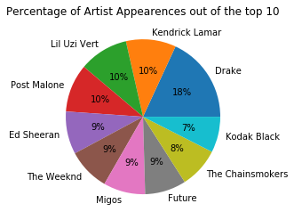

```python
top_10_artists = top_artists.head(10)
top_10_artists.plot.pie(y='Total Times on Charts', autopct='%1.0f%%', labels=top_10_artists['Artist'], legend = None)
plt.axes().set_ylabel('')
plt.title('Percentage of Artist Appearences out of the top 10')
plt.show()
```

This pie chart allows us to visualize what each top 10 artist's percentage of apperances were among the top 10. Although we already knew the order, this chart allows us to see how close everyone was asides from Drake. Another good way of representing this data would be a bar graph.

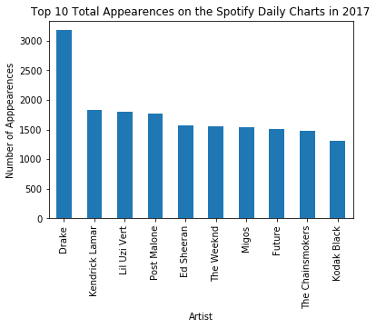

```python
top_10_artists.plot.bar(x = 'Artist', y = 'Total Times on Charts', legend = None)
plt.title('Top 10 Total Appearences on the Spotify Daily Charts in 2017')
plt.xlabel('Artist')
plt.ylabel('Number of Apppearences')
plt.show()
```

Once again, we can see that everyone is relatively close to each other, besides Drake who has distinguished himself from the pack. We have now visualized our dataset in two different ways and can make similar observations on them!

We are now ready to take a look at the dataset as a whole instead of focusing on just the top 10 artists of the year. Since the bar graph does a better job of representing totals, let's use that.

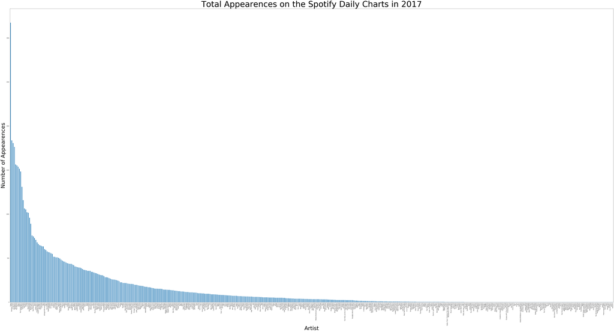

```python
top_artists.plot.bar(x = 'Artist', y = 'Total Times on Charts', legend = None, figsize = (100,50))
plt.title('Total Appearences on the Spotify Daily Charts in 2017', fontsize = 75)
plt.xlabel('Artist', fontsize = 50)
plt.ylabel('Number of Appearences', fontsize = 50)
plt.show()
```

While this bar graph provides us a lot of information, it is hard to distinguish individual artists and their corresponding values because of the huge number of artists. Let's remove the artists with less than 15 appearences on the chart to get a better look.

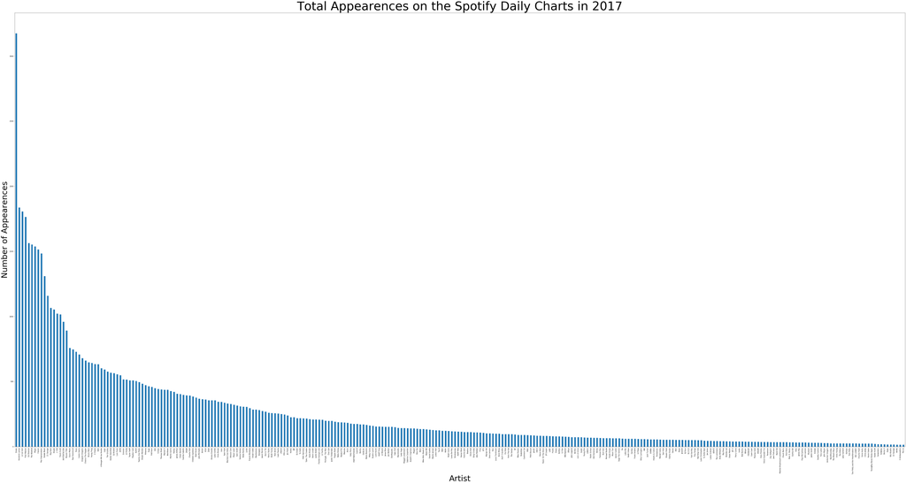

```python
top_artists_over_one = top_artists[top_artists['Total Times on Charts'] > 14]
top_artists_over_one.plot.bar(x = 'Artist', y = 'Total Times on Charts', legend = None, figsize = (100,50))
plt.title('Total Appearences on the Spotify Daily Charts in 2017', fontsize = 75)
plt.xlabel('Artist', fontsize = 50)
plt.ylabel('Number of Appearences', fontsize = 50)
plt.show()
```

This is much better as it is still showing over half of the data while giving us the opportunity to draw conclusions from our observations. We had noticed before that Drake was far ahead of everyone else and that the other 9 of the top 10 were pretty close in terms of numbers. However, that conclusion was drawn when we were only analyzing the top 10. Now that we are looking at the dataset as a whole, we can see that there is the biggest difference between those 9 as opposed to any other consecutive 9 artists. The first 18 artists all have high variance between them, but from Gucci Mane and on, there is very little difference between each artist.

Let's continue our analysis by looking at all of the number 1 songs for each day. We can create a new dataframe from our prepared dataset and filter it so that only the top song of each day is in our dataframe. We will also want to find out a) how many unique songs hit the top, and b) how many days each song was number 1 for.

```
Number of songs to reach number one: 15
```

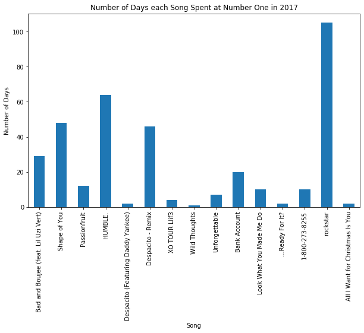

```python
number_one_songs = data[data['Position'] == 1]
number_one_songs = number_one_songs.drop(columns = ['Date', 'Streams', 'Position', 'DateTime'])
for index, row in number_one_songs.iterrows():
    number_one_songs.loc[index,'Days'] = len(number_one_songs[number_one_songs['Track Name'] == row['Track Name']])
number_one_songs = number_one_songs.drop_duplicates()
print('Number of songs to reach number one: ' + str(len(number_one_songs)))
number_one_songs.plot.bar(x = 'Track Name', y = 'Days', legend = None, figsize = (10,6))
plt.title('Number of Days each Song Spent at Number One in 2017')
plt.xlabel('Song')
plt.ylabel('Number of Days')
plt.show()
```

Glancing at the graph above we can see that among the 15 different songs to reach number one, rockstar by Post Malone was able to stay at the top for the most days in 2017. As expected, almost all of the songs found on the bar graph above were released during the years 2016 or 2017. However, All I Want for Christmas Is You by Mariah Carey also managed to hit number one for 2 days out of the year, even though it was released back in 1994. This can likely be attributed to the fact that it is the most popular holiday song in the world, and as a result, played heavily around the holiday season.

### Trends Over Time

Through this exploratory analysis, we have looked at some of the more basic statistics. Now we are going to look at how some of these positional rankings for songs create trends.

From our previous analysis, we know that rockstar held the top position for the most days, so why don't we graph it and see when it held the top position?

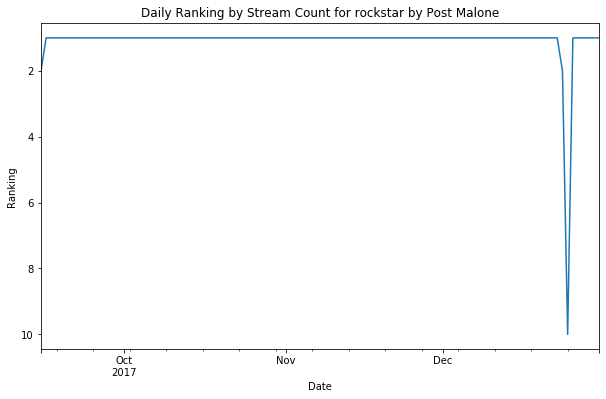

```python
rockstar_data = data[data['Track Name'] == 'rockstar']
rockstar_data.plot(x = 'DateTime', y = 'Position', legend = None, figsize = (10,6))
plt.gca().invert_yaxis()
plt.title('Daily Ranking by Stream Count for rockstar by Post Malone')
plt.xlabel('Date')
plt.ylabel('Ranking')
plt.show()
```

From the graph we can see that of the time during 2017 that rockstar was released, it was first on the daily streams chart 90% of it. It also never dipped below the top 10 for any given day, which is especially impressive. Other than that though, this graph doesn't give us a whole lot of data to analyze. So let's make a similar graph for each of the songs that hit number one one on the daily charts.

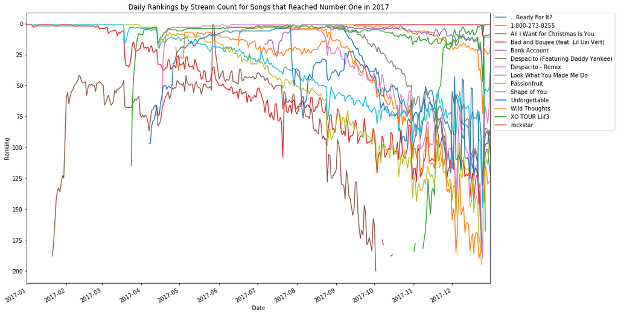

```python
num_one = ['Bad and Boujee (feat. Lil Uzi Vert)', 'Shape of You', 'Passionfruit', 'HUMBLE', \
           'Despacito (Featuring Daddy Yankee)', 'Despacito - Remix', 'XO TOUR Llif3', 'Wild Thoughts',  \
           'Unforgettable', 'Bank Account', 'Look What You Made Me Do', '...Ready For It?', '1-800-273-8255', \
           'rockstar', 'All I Want for Christmas Is You']

num_one_df = data[data['Track Name'].isin(num_one)]
num_one_df = num_one_df.pivot_table(index = 'DateTime', columns = 'Track Name', values = 'Position')
num_one_df.plot(figsize = (15,10))
plt.gca().invert_yaxis()
plt.legend(bbox_to_anchor=(1.005, 1), loc=2, borderaxespad=0.)
plt.title('Daily Rankings by Stream Count for Songs that Reached Number One in 2017')
plt.xlabel('Date')
plt.ylabel('Ranking')
plt.show()
```

Another interesting aspect of this plot is that aside from Despacito (Featuring Daddy Yankee) and All I Want for Christmas Is You, none of the other songs seem to start at the bottom of the charts, rather they just skip to the top. A lot of this can be attributed to the fact that these songs are all from mainstream artists, so they are recieving attention from the second they are released. Despacito (Featuring Daddy Yankee), the brown line, wasn't able to make this jump because Luis Fonsi, the artist, hadn't had any billboard hits since 2005, so the song didn't immediately gain attention. All I Want for Christmas Is You is not a new song, so it would never jump to the top 10 from past 200th. It also only gained traction near the holiday season, implying that this is an annual jump for Mariah Carey's Christmas hit.

You might also notice that there are sometimes gaps in the lines near the bottom of the graph where the lines become segmented. This is because the dataset only tracks the top 200 songs each day. So if a song dips below that and then comes back, it won't form a V as if we were tracking it's entire ranking, it will simply stop and then pick back up once it reaches at least 200 again.

What is also interesting to recognize is the difference difference in density between January and December. We have to remember that this particular set of data is only the songs that reached the top at some point during 2017, but what does that mean in this situation? December is so crowded on this graph because songs that peaked earlier in the year are trending down. January is so empty because all of the songs that were at number one at the end of 2016 and are just beginning to trend down aren't on the graph.

On another note, let's take a look at some trendlines for our top artists. We can start by plotting a line plot for our top 10 artists based on the number of songs on the charts per day.

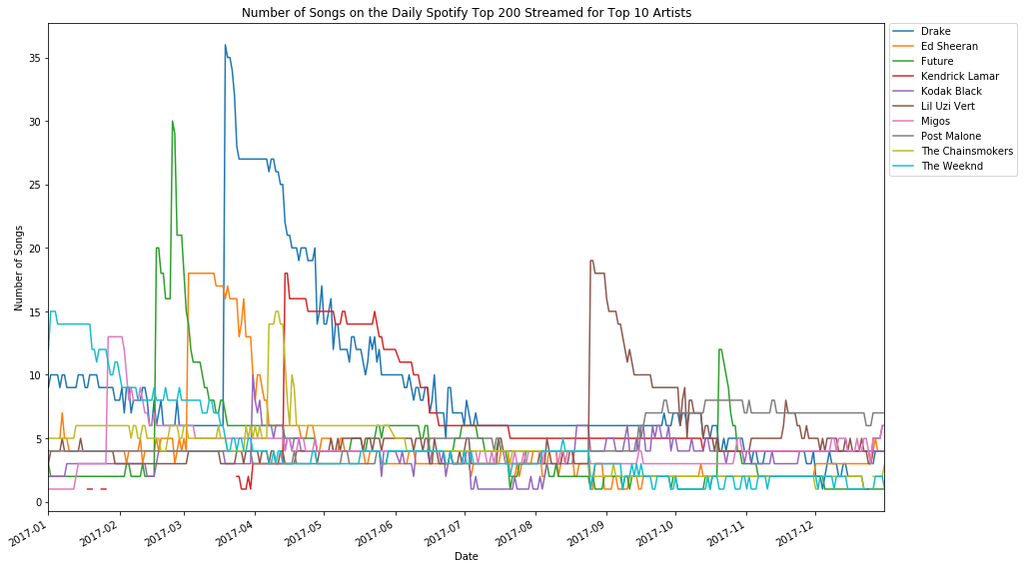

```python
top_artists_names = ['Drake', 'Kendrick Lamar', 'Lil Uzi Vert', 'Post Malone', 'Ed Sheeran', \
                     'The Weeknd', 'Migos', 'Future', 'The Chainsmokers', 'Kodak Black']
top_artists_df = data[data['Artist'].isin(top_artists_names)]
top_artists_df = top_artists_df.drop(columns = ['Streams', 'Position', 'Track Name'])
for index, row in top_artists_df.iterrows():
    filler_df = top_artists_df[top_artists_df['Date'] == row['Date']]
    top_artists_df.loc[index,'Number of Songs'] = len(filler_df[filler_df['Artist'] == row['Artist']])
top_artists_df = top_artists_df.drop_duplicates()
top_artists_df = top_artists_df.drop(columns = ['Date'])
top_artists_df = top_artists_df.pivot_table(index = 'DateTime', columns = 'Artist', values = 'Number of Songs')
top_artists_df.plot(figsize = (15,10))
plt.legend(bbox_to_anchor=(1.005, 1), loc=2, borderaxespad=0.)
plt.title('Number of Songs on the Daily Spotify Top 200 Streamed for Top 10 Artists')
plt.xlabel('Date')
plt.ylabel('Number of Songs')
plt.show()
```

As expected, we can see that Drake once again beats all of the other artists out. Something that is very interesting that I did not expect is that you can see when each artist dropped their album. For example, Drake dropped his album More Life back in March of 2017, and we can see that that pushed him up super far. He even managed to have over 35 out of the 200 most streamed songs for a day be his! Another example is Lil Uzi Vert, who dropped his album, Luv is Rage 2 back in August of 2017, and that is shown on the plot by a massive spike for him, almost propelling him to 20 songs for a day. Another artist to notice is The Weeknd, who entered 2017 with the most streams. The Weeknd released his album, Starboy, in December of 2016, so he was still riding high from his album release.

Interestingly, future had the second highest peak behind Drake, although he was 8th in the list overall based on total appearneces on the charts. This implies that although he had higher highs than most other artists, he also had lower lows.

Since Drake can so frequently be found at the top, let's take a look at his number of streams across the year. To do this, we will first create a new dataframe for only Drake songs. We will then sum the number of streams for each day and plot them.

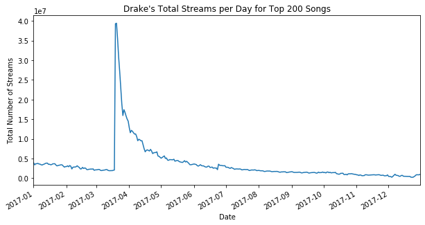

```python
drake = data[data['Artist'] == 'Drake']
drake = drake.drop(columns = ['Position', 'Track Name', 'Artist'])
for index, row in drake.iterrows():
    drake_day = drake[drake['Date'] == row['Date']]
    drake.loc[index, 'Total Streams'] = drake_day['Streams'].sum()
drake = drake.drop(columns = ['Streams'])
drake = drake.drop_duplicates()
drake.plot(x = 'DateTime', y = 'Total Streams', figsize = (10,5), legend = None)
plt.title("Drake's Total Streams per Day for Top 200 Songs")
plt.xlabel('Date')
plt.ylabel('Total Number of Streams')
plt.show()
```

Just as we saw above with the number of songs on the chart, the number of streams per day for Drake also has a massive spike in the exact same place. Once again, this spike visualizes an assumption that we could have made beforehand, the assumption being that an artist's stream count would go up when they dropped a new album. If both plots show the same information, is there a relationship between the two?

### Regressions

Now that we have explored some of the spotify music trends across time, let's see if we can find any relationships between variables. To do this we will be fitting linear regression lines to certain relationships from our dataset.

To start, let's answer the question we asked in the previous section: is there a relationship between the number of songs on the top 200, and the number of total streams for that day?

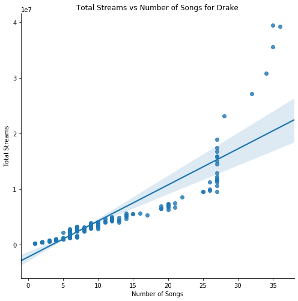

```python
drake_songs = data[data['Artist'] == 'Drake']
for index, row in drake_songs.iterrows():
    drake_songs.loc[index, 'Number of Songs'] = len(drake_songs[drake_songs['Date'] == row['Date']])
drake_songs = drake_songs.drop(columns = ['Position', 'Track Name', 'Artist', 'Streams'])
drake_songs = drake_songs.drop_duplicates()
drake = pd.merge(drake, drake_songs, on = 'Date')
sns.lmplot(x = 'Number of Songs', y = 'Total Streams', data = drake, fit_reg = True, height = 7)
plt.title('Total Streams vs Number of Songs for Drake')
plt.show()
```

As we can see from the graph above, there is definitely a positive correlation for this linear regression. But the data looks like it would lend itself to a polynomial regression line much better. Let's go ahead and graph that.

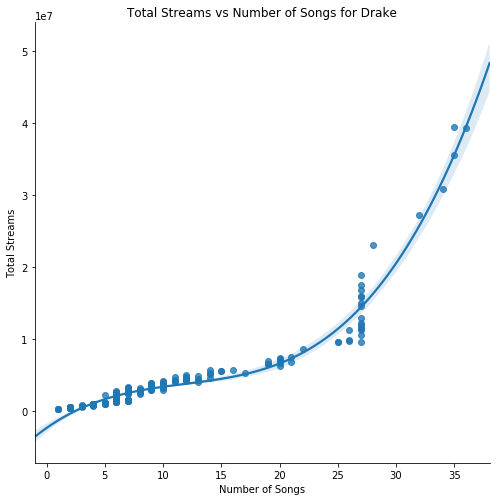

```python
sns.lmplot(x = 'Number of Songs', y = 'Total Streams', data = drake, fit_reg = True, height = 7, order = 3)
plt.title('Total Streams vs Number of Songs for Drake')
plt.show()
```

This plot is exactly what we are looking for as the curve fits the data a lot better than just a linear regression. As the number of songs increased, the total number of streams seems to be increasing at an exponential rate, which means that a linear regression isn't the ideal model for this dataset.

Let's make the same plot , but for the number of Streams vs Songs for the top 10 artists.

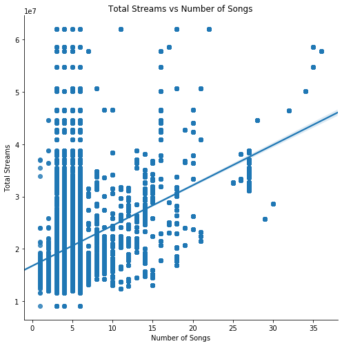

```python
top_artists_names = ['Drake', 'Kendrick Lamar', 'Lil Uzi Vert', 'Post Malone', 'Ed Sheeran', \
                     'The Weeknd', 'Migos', 'Future', 'The Chainsmokers', 'Kodak Black']
streamsvssongs = data[data['Artist'].isin(top_artists_names)]
streamsvssongs = streamsvssongs.drop(columns = ['Position', 'Track Name'])
for index, row in streamsvssongs.iterrows():
    today = streamsvssongs[streamsvssongs['Date'] == row['Date']]
    streamsvssongs.loc[index, 'Total Streams'] = today['Streams'].sum()
    streamsvssongs.loc[index, 'Number of Songs'] = len(today[today['Artist'] == row['Artist']])
sns.lmplot(x = 'Number of Songs', y = 'Total Streams', data = streamsvssongs, fit_reg = True, height = 7)
plt.title('Total Streams vs Number of Songs')
plt.show()
```

Wow, that graph is very difficult to read! Although the linear regression line does represent the trend that we expected to see. The trendline confirms our suspicion of a positive correlation between Total Streams and Number of Songs.

But this graph is too messy to do any actual analysis on it, so let's make a box plot with the same data.

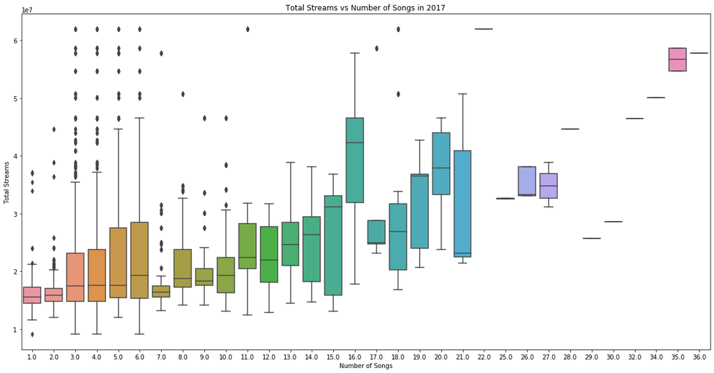

```python
sns.boxplot(x = 'Number of Songs', y = 'Total Streams', data = streamsvssongs)
fig = plt.gcf()
fig.set_size_inches( 20, 10)
plt.title('Total Streams vs Number of Songs in 2017')
plt.show()
```

The box plot above shows the positive correlation we noticed earlier even without a regression line. The box plot does a good job of showing where the bulk of the datapoints are located, while still recognizing that there are a lot of outliers. The plot shows us that there is an upward trend, which is exactly what we expected. We can also see that there are plenty of data points representing a few songs, with a lot of streams, but no data points representing a lot of songs with very few streams. That means that many of these top artists are relying on a few big hit songs to be played over and over again, rather than just many different songs getting played an even amount.

## Conclusion

Throuhout this tuorial, we used data collection processes and exploratory analysis to dive into the Spotify charts. We looked at many of the basic statistics of the daily charts, graphed trend lines to look for patters over time, and plotted regression lines to find relationships between variables. We found that Drake was the king of music in America in 2017. He dropped one of his most popular albums in 2017, and it showed in the data. Every time we tried to identify a top artist based on a certain condition, Drake was the result. Although we weren't looking for the release dates of albums, we could find them by looking at spikes for popular artists whose album's recieved attention immediately upon release. We were also able to find a positive correlation between the number of songs on the charts and the number of streams, just as we expected.

Music has and will continue to be a large and important aspect of people's lives, and we are finally getting to the point where the data surrounding music is available for us to analyze. Streaming platforms have given us ways to analyze data that was previously impossible. Data Science is also becoming a larger and larger part of society, and combining the two can result in cool projects.

Thank you for taking the time to follow along with this tutorial. Now that you are done following along, I encourage you to analyze your own dataset. Choose a subject you are passionate about and I think you'll suprise yourself!